# R Boot Camp

Chris Woolery

This class is for people who are new to R but also:

- Have intermediate to expert skills in Excel
- Are familiar with basic to intermediate statistics
- Have basic to intermediate skills in some programming language

We will generally be following “R For Data Science” at: https://r4ds.had.co.nz/ which is a much better comprehensive guide than this class.

This class will skip some concepts and accelerate you through this book covering about 50% of what is there. I advise going back and skimming through the things that do not look familiar as they will absolutely come up later in your R journey.

# DAY 4

Let’s load up some new publicly available data

```r
# Read a table where every row is an AirBnb Location in Barcelona Spain from Kaggle
# https://www.kaggle.com/datasets/zakariaeyoussefi/barcelona-airbnb-listings-inside-airbnb

# We could read the file and have R auto-assign data types based on the first 1000 and clean up the column names
# but we'll do that in advance to save time
# janitor::clean_names(NameOfDataset, case = "upper_camel") was used to get clean up the column names
#

Airbnb_ColNames = c("RowID", "PropertyId", "HostId", "HostIsSuperhost", "HostListingsCount", "Neighbourhood", "Zipcode", "Latitude", "Longitude", "PropertyType", "RoomType", "Accommodates", "Bathrooms", "Bedrooms", "Beds", "Amenities", "Price", "MinimumNights", "HasAvailability", "Availability30", "Availability60", "Availability90", "Availability365", "NumberOfReviewsLtm", "ReviewScoresRating")
Airbnb_ColTypes = c("nnnlnccnnccnnnnccnlnnnnnn")

demo_Airbnb_Barcelona <- readr::read_csv('https://raw.githubusercontent.com/RJETAnalytics/TrainingDemo/main/demo_Airbnb_Barcelona.csv',
                     col_types = Airbnb_ColTypes,
                     col_names = Airbnb_ColNames,
                     skip = 1)

#Clean up Amenities column and create 1 row per Amenities Data Frame
Airbnb_Amenities = demo_Airbnb_Barcelona %>%
  select(PropertyId, Amenities) %>%
  mutate(Amenities = str_remove_all(Amenities, "\\[|\\]")) %>%
  # separate_rows splits a field from 1 row into many based on a delimiter
  separate_rows(Amenities, sep = ", ") %>%
  # remove all \\W aka non-word characters
  mutate(Amenities = str_remove_all(Amenities, "\\W"),
         Amenities = paste0("Has", Amenities),
         HasAmenity = 1)

AGGAirbnb_Property_Amenities = Airbnb_Amenities %>%
  group_by(PropertyId) %>%
  summarize(AmenityCount = n(), .groups = "drop")

#Re-aggregate and rank to top 25 amenities by occurance
AGGAirbnb_Amenities = Airbnb_Amenities %>%
  group_by(Amenities) %>%
  summarize(AmenityCount = n(), .groups = "drop") %>%
  arrange(desc(AmenityCount)) %>%
  mutate(AmenityRank = row_number()) %>%
  filter(AmenityRank <= 25)

#Join back to Property ID by Amenity which by inner join gives us only top 25
#then pivot wider so that we have 1 rows per property with 1/0 for presence of the amenity
Airbnb_Amenities = Airbnb_Amenities %>%
  inner_join(AGGAirbnb_Amenities, by = "Amenities") %>%
  # pivot wider makes 25 rows into 1 row with 25 new columns
  pivot_wider(id_cols = c(PropertyId),
              names_from = Amenities, values_from = HasAmenity,
              values_fn = sum, values_fill = 0) %>%
  janitor::clean_names(case = "upper_camel") %>%
  # change from 1/0 to TRUE/FALCE logical
  mutate_at(vars(2:26), ~ as.logical(pmin(., 1))) %>%
  left_join(AGGAirbnb_Property_Amenities, by = "PropertyId") %>%
  mutate(AmenityCount = if_else(is.na(AmenityCount), 0, AmenityCount)) %>%
  relocate(AmenityCount, .after = PropertyId)

#Re-join our top 25 amenity columns to our original table and drop the junky amenity column
AirbnbDF = demo_Airbnb_Barcelona %>%
  select(-Amenities) %>%
  inner_join(Airbnb_Amenities, by = c("PropertyId"))

# Barcelona Central Plaza "Plaça de Catalunya" will be considered the City Center
CityCenter = tibble(LAT = 41.386553466894135, LONG = 2.170042714240173)

# Clean up data types and create defaults for NA values
# Character fields like Property Type and Neighbourhood that have finite values
# are converted to factors so that they can be used for prediction
# Add distance to city center
AirbnbDF = AirbnbDF %>%
  filter(!is.na(Neighbourhood)) %>%
  select(-c(Zipcode)) %>%
  mutate(HostIsSuperhost = if_else(is.na(HostIsSuperhost), FALSE, HostIsSuperhost),
         HostListingsCount = if_else(is.na(HostListingsCount), 0, HostListingsCount),
         Neighbourhood = factor(Neighbourhood),
         PropertyType = factor(PropertyType),
         RoomType = factor(RoomType),
         Bathrooms = if_else(is.na(Bathrooms), 0, Bathrooms) %>% as.numeric(),
         Bedrooms = if_else(is.na(Bedrooms), 0, Bedrooms) %>% as.numeric(),
         Beds = if_else(is.na(Beds), 0, Beds) %>% as.numeric(),
         Price = str_remove_all(Price, "\\$|\\,") %>% as.numeric(),
         ReviewScoresRating = if_else(is.na(ReviewScoresRating),
                                      median(ReviewScoresRating, na.rm = T),
                                      ReviewScoresRating),
         CityCenterDistance = DistMiles(Latitude, Longitude, CityCenter$LAT, CityCenter$LONG)) %>%
  relocate(CityCenterDistance, .after = Longitude)

# Defaulting to "Other"
# Some values are so sparse that they won't be useful for our modeling so we will
# replace anything with less than
MinAllowable = 10
# using fct_collapse or factor collapse
AirbnbDF <- AirbnbDF %>%
  mutate(PropertyType = fct_collapse(PropertyType ,
                                     Other = AirbnbDF %>%
                                       count(PropertyType) %>%
                                       filter(n < MinAllowable) %>%
                                       pull(PropertyType)),
         Neighbourhood = fct_collapse(Neighbourhood ,
                                     Other = AirbnbDF %>%
                                       count(Neighbourhood) %>%
                                       filter(n < MinAllowable) %>%
                                       pull(Neighbourhood)))

# Define the non-predictive columns for later exclusion
# ID columns aren't useful, zip code and lat/long are dups to neighborhood
# Availability is always true and our pricing prediction isn't dependent
# on it's availability for a snapshot in time (maybe scarcity is a driver but ignore for now)
```

AGENDA

1. Barcelona Airbnb Properties
   1. Join our rank and features data and filter to relevant columns
   2. Explore the data and visualize
   3. Build a linear model
   4. See if the linear model is predictive for price using test and train splits
2. Discuss Other Model Types
   1. AOV
   2. Classification versus Regression
   3. Logistic Regression
   4. Tree Models and other more complex models
3. Missed Concepts
   1. If … Then and case … when will be covered while manipulating the data in the prediction datasets

Explore the AirbnbDF

```r
summary(AirbnbDF)
```

```
##      RowID         PropertyId           HostId          HostIsSuperhost
##  Min.   :    0   Min.   :   18666   Min.   :     3073   Mode :logical
##  1st Qu.: 4967   1st Qu.:11828008   1st Qu.:  7586124   FALSE:16071
##  Median : 9934   Median :22409838   Median : 43565515   TRUE :3697
##  Mean   : 9925   Mean   :20977326   Mean   : 86544476
##  3rd Qu.:14882   3rd Qu.:31572251   3rd Qu.:160978331
##  Max.   :19832   Max.   :36582760   Max.   :274862556
##
##  HostListingsCount             Neighbourhood     Latitude       Longitude
##  Min.   :   0.00   Eixample           :3752   Min.   :41.35   Min.   :2.093
##  1st Qu.:   1.00   Ciutat Vella       :2448   1st Qu.:41.38   1st Qu.:2.157
##  Median :   3.00   Sants-Montjuïc     :1838   Median :41.39   Median :2.168
##  Mean   :  20.38   Sant Martí         :1140   Mean   :41.39   Mean   :2.168
##  3rd Qu.:  12.00   Gràcia             : 881   3rd Qu.:41.40   3rd Qu.:2.178
##  Max.   :1411.00   Dreta de l'Eixample: 863   Max.   :41.46   Max.   :2.229
##                    (Other)            :8846
##  CityCenterDistance             PropertyType              RoomType
##  Min.   :0.01619    Apartment         :16796   Entire home/apt: 9462
##  1st Qu.:0.61075    Serviced apartment:  688   Private room   :10098
##  Median :1.01381    Loft              :  466   Shared room    :  208
##  Mean   :1.18916    House             :  375
##  3rd Qu.:1.60940    Condominium       :  361
##  Max.   :5.23657    Bed and breakfast :  219
##                     (Other)           :  863
##   Accommodates      Bathrooms         Bedrooms           Beds
##  Min.   : 1.000   Min.   : 0.000   Min.   : 0.000   Min.   : 0.000
##  1st Qu.: 2.000   1st Qu.: 1.000   1st Qu.: 1.000   1st Qu.: 1.000
##  Median : 2.000   Median : 1.000   Median : 1.000   Median : 2.000
##  Mean   : 3.351   Mean   : 1.318   Mean   : 1.568   Mean   : 2.256
##  3rd Qu.: 4.000   3rd Qu.: 1.500   3rd Qu.: 2.000   3rd Qu.: 3.000
##  Max.   :18.000   Max.   :16.000   Max.   :16.000   Max.   :40.000
##
##      Price        MinimumNights    HasAvailability Availability30
##  Min.   :   7.0   Min.   :  1.00   Mode:logical    Min.   : 0.00
##  1st Qu.:  40.0   1st Qu.:  1.00   TRUE:19768      1st Qu.: 0.00
##  Median :  65.0   Median :  2.00                   Median : 5.00
##  Mean   : 129.8   Mean   :  8.54                   Mean   : 8.25
##  3rd Qu.: 113.0   3rd Qu.:  4.00                   3rd Qu.:13.00
##  Max.   :9120.0   Max.   :900.00                   Max.   :30.00
##
```

[output cut: 49 more lines]

```
##  Mode :logical   Mode :logical   Mode :logical          Mode :logical
##  FALSE:12654     FALSE:11479     FALSE:11975            FALSE:13029
##  TRUE :7114      TRUE :8289      TRUE :7793             TRUE :6739
##
##
##
##
##   HasOven         HasStove       HasNostairsorstepstoenter
##  Mode :logical   Mode :logical   Mode :logical
##  FALSE:13294     FALSE:14143     FALSE:17410
##  TRUE :6474      TRUE :5625      TRUE :2358
##
##
##
##
```

Explore the thing we want to predict which is the price

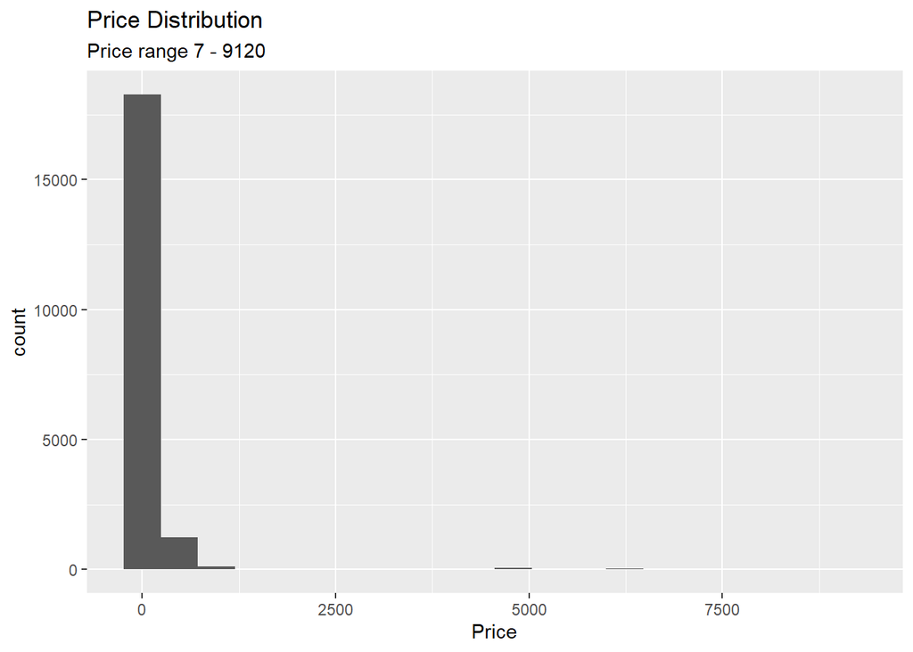

```r
AirbnbDF %>%
  ggplot() +
    geom_histogram(aes(Price), bins = 20) +
    labs(title = "Price Distribution",
         subtitle = paste0("Price range ", min(AirbnbDF$Price), " - ", max(AirbnbDF$Price)))
```

Given the extreem outliers in high price, we might reset our goal to predict prices for the lower 95%

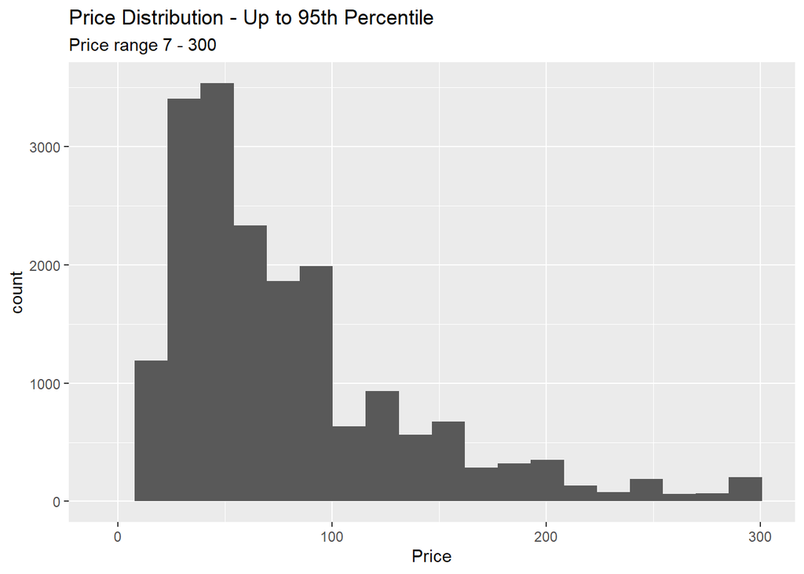

```r
AirbnbDF %>%
  filter(Price <= quantile(AirbnbDF$Price, 0.95)) %>%
  ggplot() +
    geom_histogram(aes(Price), bins = 20) +
    labs(title = "Price Distribution - Up to 95th Percentile",
         subtitle = paste0("Price range ", min(AirbnbDF$Price),
                           " - ", max(AirbnbDF$Price[AirbnbDF$Price<=quantile(AirbnbDF$Price, 0.95)])))
```

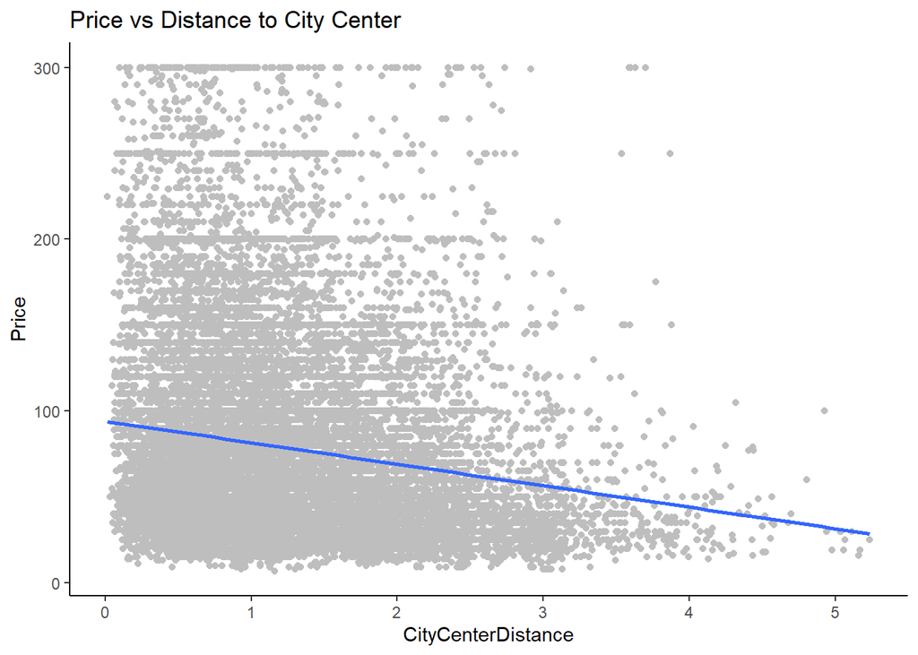

```r
AirbnbDF %>%
  filter(Price <= quantile(AirbnbDF$Price, 0.95)) %>%
  ggplot(aes(CityCenterDistance, Price)) +
    geom_point(color = "grey") +
    geom_smooth(method = "lm", formula = 'y ~ x', se = F) +
    theme_classic() +
    labs(title = "Price vs Distance to City Center")
```

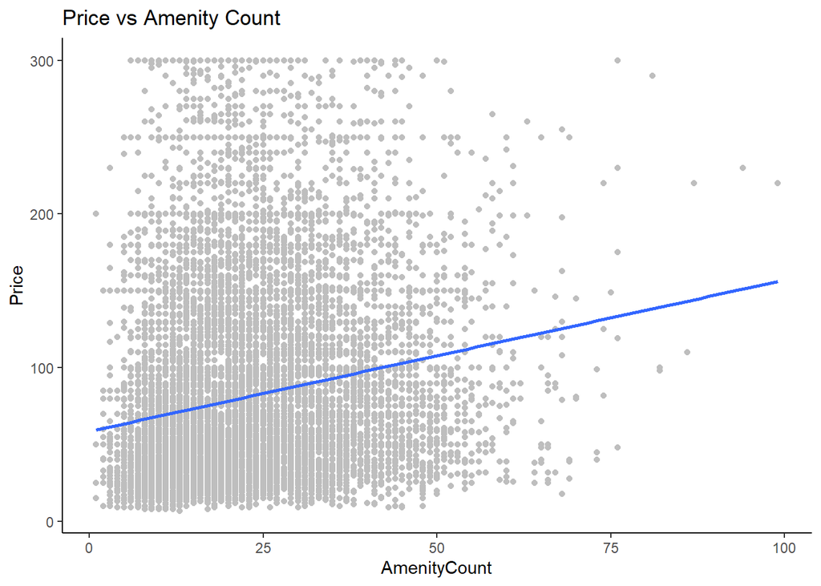

```r
AirbnbDF %>%
  filter(Price <= quantile(AirbnbDF$Price, 0.95)) %>%
  ggplot(aes(AmenityCount, Price)) +
    geom_point(color = "grey") +
    geom_smooth(method = "lm", formula = 'y ~ x', se = F) +
    theme_classic() +
    labs(title = "Price vs Amenity Count")
```

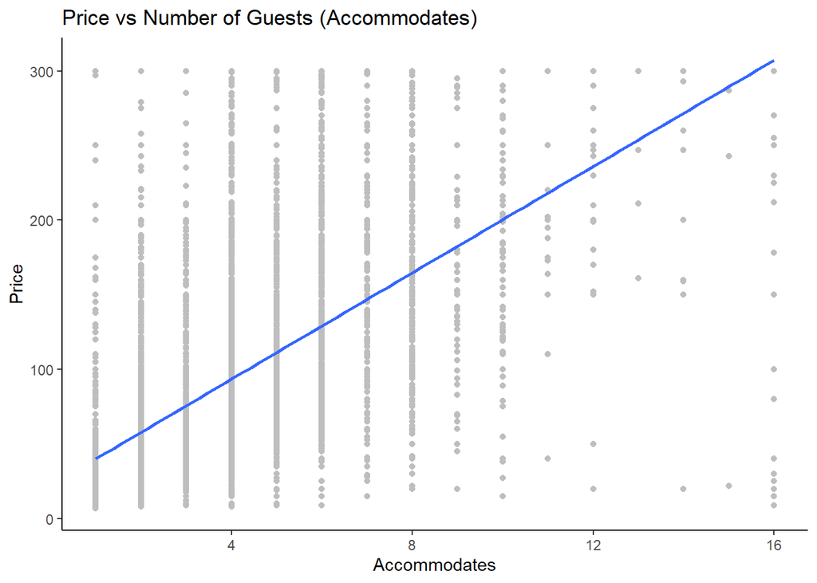

```r
AirbnbDF %>%
  filter(Price <= quantile(AirbnbDF$Price, 0.95)) %>%
  ggplot(aes(Accommodates, Price)) +
    geom_point(color = "grey") +
    geom_smooth(method = "lm", formula = 'y ~ x', se = F) +
    theme_classic() +
    labs(title = "Price vs Number of Guests (Accommodates)")
```

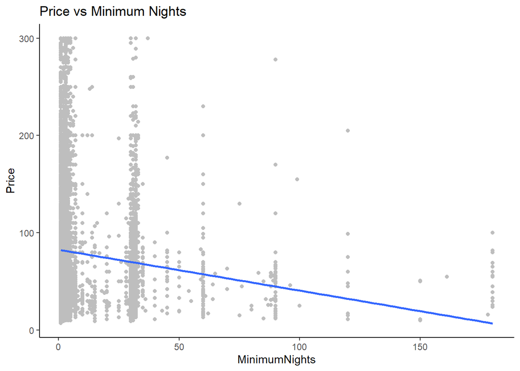

```r
AirbnbDF %>%
  filter(Price <= quantile(AirbnbDF$Price, 0.95)) %>%
  filter(MinimumNights <= 180) %>%
  ggplot(aes(MinimumNights, Price)) +
    geom_point(color = "grey") +
    geom_smooth(method = "lm", formula = 'y ~ x', se = F) +
    theme_classic() +
    labs(title = "Price vs Minimum Nights")
```

```r
AirbnbDF_Clean = AirbnbDF %>%
  filter(Price <= quantile(AirbnbDF$Price, 0.95)) %>%
  filter(MinimumNights <= 180) %>%
  relocate(Price, .after = HostId) %>%
  select(-RowID)

Airbnb_LM = lm(Price ~ CityCenterDistance + AmenityCount + Accommodates,
               data = AirbnbDF_Clean)

summary(Airbnb_LM)
```

```
##
## Call:
## lm(formula = Price ~ CityCenterDistance + AmenityCount + Accommodates,
##     data = AirbnbDF_Clean)
##
## Residuals:
##      Min       1Q   Median       3Q      Max
## -286.396  -23.840   -8.884   13.326  267.563
##
## Coefficients:
##                    Estimate Std. Error t value            Pr(>|t|)
## (Intercept)        29.01431    0.94602  30.670 <0.0000000000000002 ***
## CityCenterDistance -9.02948    0.42375 -21.309 <0.0000000000000002 ***
## AmenityCount        0.29246    0.02997   9.759 <0.0000000000000002 ***
## Accommodates       17.17523    0.16560 103.717 <0.0000000000000002 ***
## ---
## Signif. codes:  0 '***' 0.001 '**' 0.01 '*' 0.05 '.' 0.1 ' ' 1
##
## Residual standard error: 43.89 on 18772 degrees of freedom
## Multiple R-squared:  0.406,  Adjusted R-squared:  0.4059
## F-statistic:  4276 on 3 and 18772 DF,  p-value: < 0.00000000000000022
```

This formula tells us that:

Price = 29.01431 + -9.02948 * City Center Distance + 0.29246 * Amenity Count  
+ 17.17523 * Accommodates

Let’s explore the relationship between our target, predictors and the regression model we’ve built.

Now add the data from the model object

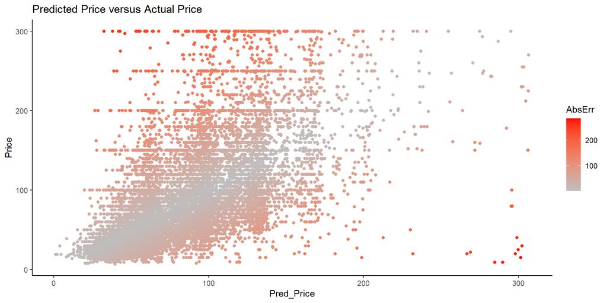

```r
AirbnbDF_Clean %>%
  mutate(Pred_Price = Airbnb_LM$fitted.values,
         AbsErr = abs(Pred_Price - Price)) %>%
  ggplot(aes(Pred_Price, Price)) +
    geom_point(aes(color = AbsErr)) +
#    geom_smooth(method = "lm", formula = "y ~ x", se = FALSE, size = 2, color = "pink") +
    scale_color_gradient(low = "grey", high = "red") +
    theme_classic() +
    labs(title = "Predicted Price versus Actual Price")
```

We can store the model object

```r
SaveFile = "C:\\Users\\Chris.Woolery\\OneDrive - Republic Airways\\Documents\\2024\\Airbnb_LM.RDATA"

saveRDS(Airbnb_LM, SaveFile)

x = readRDS(SaveFile)
```

We can plot the residuals (error between predicted and actual) ourselves to see what the bias in the variance is

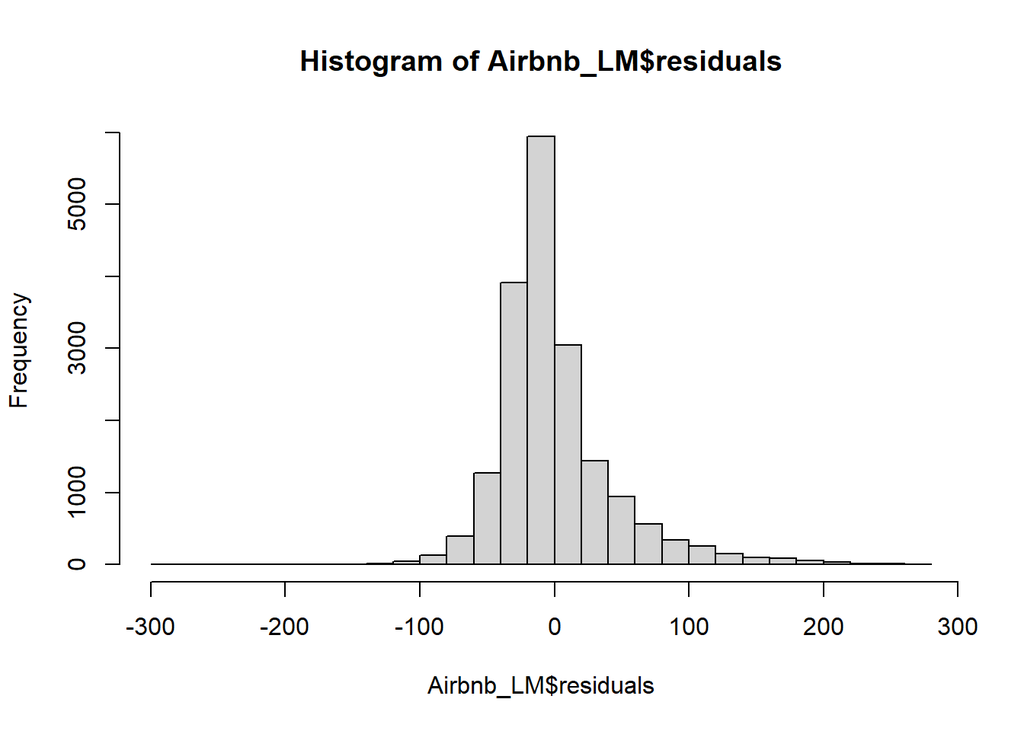

```r
hist(Airbnb_LM$residuals, breaks = 30)
```

An R also has some nice default plots for most models

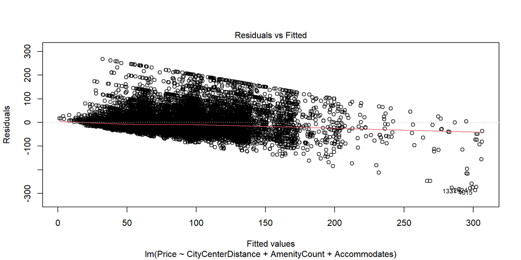

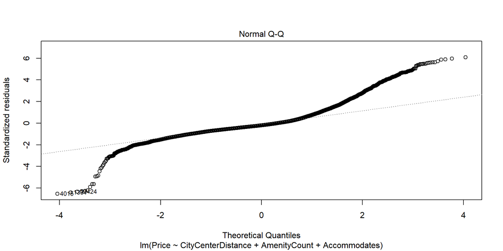

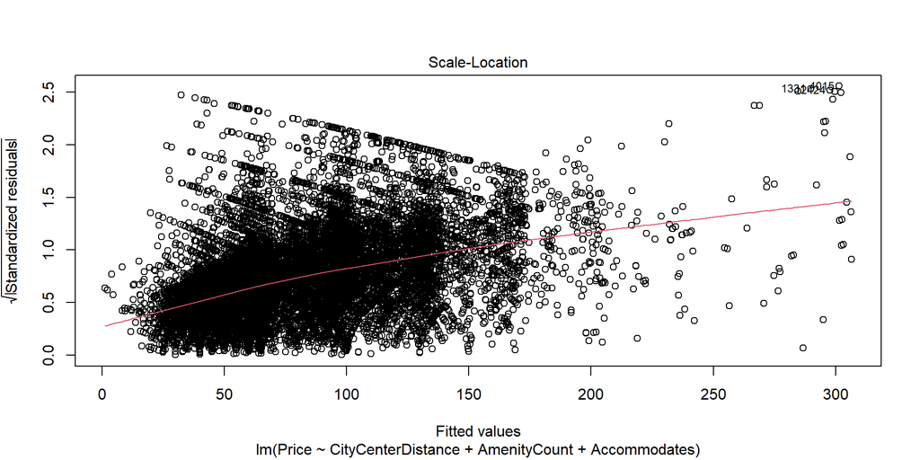

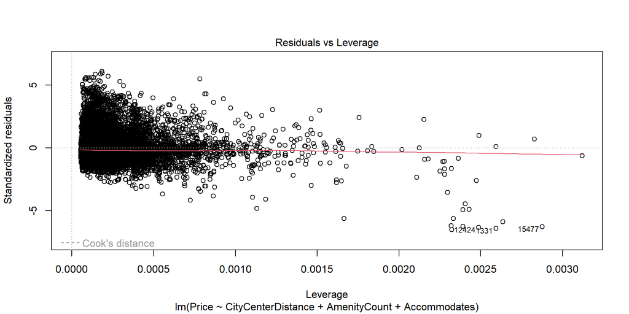

```r
plot(Airbnb_LM)
```

```r
library(caret)
set.seed(46268)
PartIndex = createDataPartition(AirbnbDF_Clean$Price, times = 1,
                                 p = 0.7, list = FALSE)

AirbnbDF_Clean = AirbnbDF_Clean %>%
  mutate(RowID = row_number(),
         SetName = as.factor(if_else(RowID %in% PartIndex, "Train", "Test"))) %>%
  dplyr::relocate(c(RowID, SetName), .before = everything()) %>%
  filter(complete.cases(.))

AirbnbDF_Clean %>%
  filter(SetName == "Train") %>%
  pull(Price) %>%
  summary()
```

```
##    Min. 1st Qu.  Median    Mean 3rd Qu.    Max.
##    7.00   39.00   60.00   79.36  100.00  300.00
```

```r
AirbnbDF_Clean %>%
  filter(SetName == "Test") %>%
  pull(Price) %>%
  summary()
```

```
##    Min. 1st Qu.  Median    Mean 3rd Qu.    Max.
##    8.00   39.00   60.00   78.78  100.00  300.00
```

```r
AirbnbDF_Train = AirbnbDF_Clean %>%
  filter(SetName == "Train")

AirbnbDF_Test = AirbnbDF_Clean %>%
  filter(SetName == "Test")
```

Let’s introduce the concept of [cross validation](https://en.wikipedia.org/wiki/Cross-validation_%28statistics%29#/media/File:K-fold_cross_validation_EN.svg) for our training data

```r
set.seed(46268)
price.cv.folds <- createMultiFolds(AirbnbDF_Train$Price, k = 5, times = 4)

price.cv.cntrl <- trainControl(method = "repeatedcv", number = 5,
                         repeats = 4, index = price.cv.folds)

Airbnb_LM_Small <- train(Price ~ CityCenterDistance + AmenityCount + Accommodates
                   + HostIsSuperhost,
                           data = AirbnbDF_Train,
                           method="lm",
                           trControl = price.cv.cntrl)

summary(Airbnb_LM_Small$finalModel)
```

```
##
## Call:
## lm(formula = .outcome ~ ., data = dat)
##
## Residuals:
##      Min       1Q   Median       3Q      Max
## -282.923  -23.680   -8.975   13.255  267.859
##
## Coefficients:
##                     Estimate Std. Error t value             Pr(>|t|)
## (Intercept)         27.93155    1.13623  24.583 < 0.0000000000000002 ***
## CityCenterDistance  -8.49197    0.50505 -16.814 < 0.0000000000000002 ***
## AmenityCount         0.26439    0.03764   7.024     0.00000000000226 ***
## Accommodates        17.33508    0.19725  87.886 < 0.0000000000000002 ***
## HostIsSuperhostTRUE  2.67425    1.03340   2.588              0.00967 **
## ---
## Signif. codes:  0 '***' 0.001 '**' 0.01 '*' 0.05 '.' 0.1 ' ' 1
##
## Residual standard error: 43.95 on 13140 degrees of freedom
## Multiple R-squared:  0.4097, Adjusted R-squared:  0.4095
## F-statistic:  2280 on 4 and 13140 DF,  p-value: < 0.00000000000000022
```

But we want to show an example of using a full featured model

```r
NonPredictiveColumns = c("RowID", "SetName", "PropertyId", "HostId", "ZipCode",
                         "Latitude", "Longitude", "HasAvailability",
                         "Availability30", "Availability60", "Availability90",
                         "Availability365",
                         "Neighbourhood", "RoomType")

Airbnb_LM <- train(Price ~ .,
                           data = AirbnbDF_Train  %>%
                                    select(-any_of(NonPredictiveColumns)),
                           method="lm",
                           trControl = price.cv.cntrl)

summary(Airbnb_LM$finalModel)
```

```
##
## Call:
## lm(formula = .outcome ~ ., data = dat)
##
## Residuals:
##      Min       1Q   Median       3Q      Max
## -282.667  -23.331   -6.362   14.185  247.961
##
## Coefficients:
##                                         Estimate  Std. Error t value
## (Intercept)                           37.2271434   8.7437872   4.258
## HostIsSuperhostTRUE                    2.2421202   1.0527294   2.130
## HostListingsCount                     -0.0000492   0.0075674  -0.007
## CityCenterDistance                    -8.3102863   0.4970808 -16.718
## PropertyTypeApartment                -13.3820910   7.1842294  -1.863
## PropertyTypeOther                    -15.9561221   8.8181452  -1.809
## `PropertyTypeBed and breakfast`      -20.2566776   7.9969663  -2.533
## PropertyTypeBoat                      12.2303483  11.0035190   1.111
## `PropertyTypeBoutique hotel`          28.8285247   9.5304366   3.025
## `PropertyTypeCasa particular (Cuba)` -15.6704383  10.5271989  -1.489
## PropertyTypeCondominium               -3.9994613   7.6516399  -0.523
## `PropertyTypeGuest suite`            -12.8134272   8.1866769  -1.565
## PropertyTypeGuesthouse               -20.2653948  10.7468331  -1.886
## PropertyTypeHostel                     4.0964266   8.2128189   0.499
## PropertyTypeHotel                     52.6445009  13.5843505   3.875
## PropertyTypeHouse                     -8.0679223   7.6631074  -1.053
## PropertyTypeLoft                      -3.7890367   7.5450015  -0.502
## `PropertyTypeServiced apartment`       6.6315526   7.4657496   0.888
## PropertyTypeTownhouse                 11.5607157  11.2610659   1.027
## PropertyTypeVilla                     -1.1187415  14.0054645  -0.080
## Accommodates                          14.2843258   0.3930211  36.345
## Bathrooms                              0.4875606   0.6858663   0.711
## Bedrooms                               5.2686493   0.6886478   7.651
## Beds                                  -2.0699952   0.4490686  -4.610
## MinimumNights                         -0.5929954   0.0264257 -22.440
## NumberOfReviewsLtm                    -0.1965175   0.0237129  -8.287
## ReviewScoresRating                     0.1779085   0.0455869   3.903
## AmenityCount                           0.2663150   0.0857971   3.104
## HasTvTRUE                              3.6810135   0.9384480   3.922
## HasWifiTRUE                          -11.1707077   2.5944905  -4.306
```

[output cut: 68 more lines]

```
## HasBedlinensTRUE                                 0.700878
## HasMicrowaveTRUE                                 0.728419
## HasCoffeemakerTRUE                               0.005018 **
## HasRefrigeratorTRUE                              0.026221 *
## HasDishesandsilverwareTRUE                       0.000630 ***
## HasCookingbasicsTRUE                             0.010563 *
## HasOvenTRUE                                      0.000738 ***
## HasStoveTRUE                                     0.465270
## HasNostairsorstepstoenterTRUE          0.0000469337798714 ***
## ---
## Signif. codes:  0 '***' 0.001 '**' 0.01 '*' 0.05 '.' 0.1 ' ' 1
##
## Residual standard error: 41.41 on 13092 degrees of freedom
## Multiple R-squared:  0.4779, Adjusted R-squared:  0.4758
## F-statistic: 230.4 on 52 and 13092 DF,  p-value: < 0.00000000000000022
```

```r
#Example of what predict() returns
x = predict(Airbnb_LM, newdata = AirbnbDF_Test)

#Add predictions to training and test data
ResultDF = bind_rows(AirbnbDF_Train %>%
                        mutate(Pred = predict(Airbnb_LM, AirbnbDF_Train),
                               Err = Pred - Price,
                               AbsErr = abs(Err)),
                     AirbnbDF_Test  %>%
                        mutate(Pred = predict(Airbnb_LM, AirbnbDF_Test),
                               Err = Pred - Price,
                               AbsErr = abs(Err))
                     ) %>%
  relocate(c(Pred, Err, AbsErr), .after = Price)
```

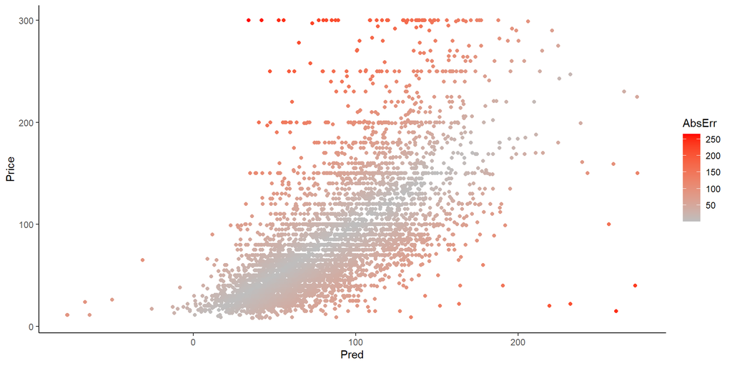

```r
ResultDF %>%
  filter(SetName == "Test") %>%
  ggplot(aes(Pred, Price)) +
    geom_point(aes(color = AbsErr)) +
    scale_color_gradient(low = "grey", high = "red") +
    theme_classic()
```

```r
Summary_ResultDF = ResultDF %>%
  group_by(SetName) %>%
  summarize(MeanPred = round(mean(Pred), 3),
            MeanPrice = round(mean(Price), 3),
            ME = round(mean(Err), 3),
            MAE = round(mean(AbsErr), 3),
            MAPE = round(MAE / mean(Price), 3),
            RMSE = round(sqrt(mean(Err^2)), 3),
            PctErrUnder25 = sum(if_else(AbsErr / Price <= 0.25, 1, 0)) / n(),
            .groups = "drop")

Summary_ResultDF
```

| SetName | MeanPred | MeanPrice | ME | MAE | MAPE | RMSE | PctErrUnder25 |
| --- | --- | --- | --- | --- | --- | --- | --- |
| Test | 78.823 | 78.775 | 0.048 | 28.343 | 0.36 | 41.078 | 0.4098739 |
| Train | 79.357 | 79.357 | 0.000 | 28.601 | 0.36 | 41.330 | 0.4127805 |

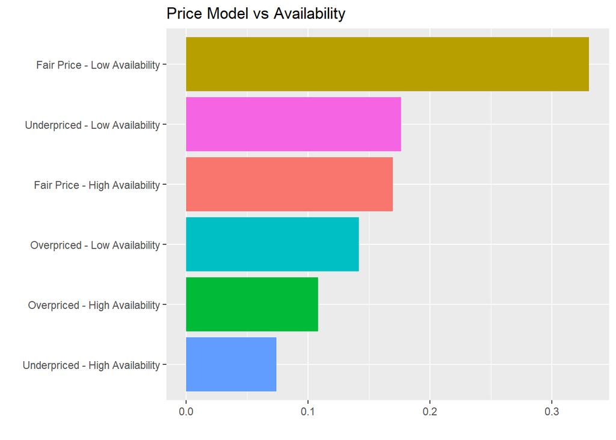

```r
DisplayDF = ResultDF %>%
  mutate(Timeframe = Availability30 / 30,
         Category = case_when(Err > quantile(Err, 0.75) &
                              Timeframe > mean(Timeframe)  ~ "Underpriced - High Availability",
                              Err > quantile(Err, 0.75) &
                              Timeframe <= mean(Timeframe) ~ "Underpriced - Low Availability",
                              Err <= quantile(Err, 0.25) &
                              Timeframe > mean(Timeframe) ~ "Overpriced - High Availability",
                              Err <= quantile(Err, 0.25) &
                              Timeframe <= mean(Timeframe) ~ "Overpriced - Low Availability",
                              Timeframe <= mean(Timeframe) ~ "Fair Price - Low Availability",
                              Timeframe > mean(Timeframe) ~  "Fair Price - High Availability",
                              TRUE ~ "Other") %>% factor(),
         )

DisplayDF%>%
  group_by(Category) %>%
  summarize(n = n(), .groups = "drop") %>%
  mutate(Percentage = n / sum(n)) %>%
  ggplot(aes(reorder(Category, Percentage), Percentage)) +
  geom_col(aes(fill = Category)) +
  coord_flip() +
  theme(legend.position = "none") +
  labs(title = "Price Model vs Availability",
       x = "", y = "")
```

You could view and explore some of the Underpriced properties

```r
DisplayDF %>%
  filter(Err > 50) %>%
  arrange(desc(Err)) %>%
  View()
```

Now some publicly available data for Classification

```r
# Read a table where every row is an bank customer with some data and if they left the bank
# https://www.kaggle.com/datasets/saurabhbadole/bank-customer-churn-prediction-dataset

# We could read the file and have R auto-assign data types based on the first 1000 and clean up the column names
# but we'll do that in advance to save time
# No column name clean-up was needed as these were already in upper camel
#

BankChurn_ColTypes = c("nncnccnnnnnnnn")

demo_BankChurn <- readr::read_csv('https://raw.githubusercontent.com/RJETAnalytics/TrainingDemo/main/demo_BankChurn.csv', col_types = BankChurn_ColTypes)

# Some general data clean-up
BankChurnDF = demo_BankChurn %>%
  mutate(Geography = factor(Geography),
         Gender = factor(Gender),
         HasCrCard = as.logical(HasCrCard),
         IsActiveMember = as.logical(IsActiveMember),
         Result = if_else(Exited == 1, "Exited", "Retained") %>% factor()) %>%
  select(-c(Exited, Surname, -RowNumber)) %>%
  relocate(Result, .before = everything())
```

Explore the data

```r
summary(BankChurnDF)
```

```
##       Result       RowNumber       CustomerId        CreditScore
##  Exited  :2037   Min.   :    1   Min.   :15565701   Min.   :350.0
##  Retained:7963   1st Qu.: 2501   1st Qu.:15628528   1st Qu.:584.0
##                  Median : 5000   Median :15690738   Median :652.0
##                  Mean   : 5000   Mean   :15690941   Mean   :650.5
##                  3rd Qu.: 7500   3rd Qu.:15753234   3rd Qu.:718.0
##                  Max.   :10000   Max.   :15815690   Max.   :850.0
##    Geography       Gender          Age            Tenure          Balance
##  France :5014   Female:4543   Min.   :18.00   Min.   : 0.000   Min.   :     0
##  Germany:2509   Male  :5457   1st Qu.:32.00   1st Qu.: 3.000   1st Qu.:     0
##  Spain  :2477                 Median :37.00   Median : 5.000   Median : 97199
##                               Mean   :38.92   Mean   : 5.013   Mean   : 76486
##                               3rd Qu.:44.00   3rd Qu.: 7.000   3rd Qu.:127644
##                               Max.   :92.00   Max.   :10.000   Max.   :250898
##  NumOfProducts  HasCrCard       IsActiveMember  EstimatedSalary
##  Min.   :1.00   Mode :logical   Mode :logical   Min.   :    11.58
##  1st Qu.:1.00   FALSE:2945      FALSE:4849      1st Qu.: 51002.11
##  Median :1.00   TRUE :7055      TRUE :5151      Median :100193.91
##  Mean   :1.53                                   Mean   :100090.24
##  3rd Qu.:2.00                                   3rd Qu.:149388.25
##  Max.   :4.00                                   Max.   :199992.48
```

Compare the Result to some of our predictor variables

First Numeric Variables with box plots

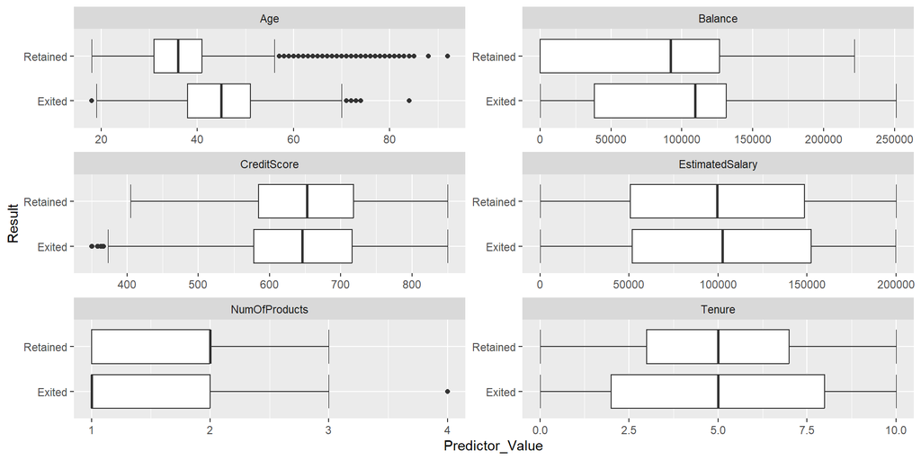

```r
DisplayDF = BankChurnDF %>%
  select(CustomerId, Result, CreditScore, Age, Tenure, Balance, NumOfProducts, EstimatedSalary) %>%
  pivot_longer(cols = -c(CustomerId, Result), names_to = "Predictor_Name", values_to = "Predictor_Value")

DisplayDF %>%
  ggplot(aes(Result, Predictor_Value)) +
    stat_boxplot(geom ='errorbar', size = 0.2) +
    geom_boxplot() +
    facet_wrap(~Predictor_Name, ncol = 2, scales = "free") +
    coord_flip()
```

Then Factors with column plots

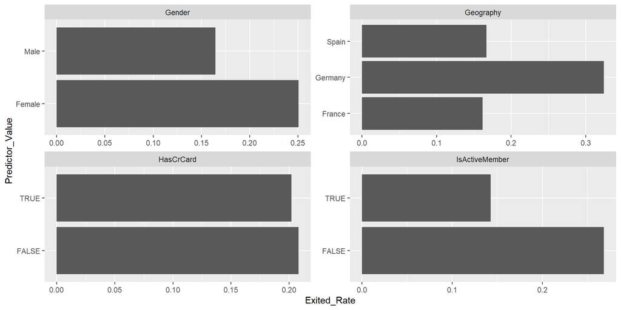

```r
DisplayDF = BankChurnDF %>%
  # We'll plan on having a count for retained vs Exited
  # and convert logical to factor to make plots
  mutate(Retained = if_else(Result == "Retained", 1, 0),
         Exited = if_else(Result == "Exited", 1, 0),
         HasCrCard = factor(HasCrCard),
         IsActiveMember = factor(IsActiveMember)) %>%
  # Select just factors
  select(Retained, Exited, Geography, Gender, HasCrCard, IsActiveMember) %>%
  # Unpivot
  pivot_longer(cols = -c(Retained, Exited), names_to = "Predictor_Name", values_to = "Predictor_Value") %>%

  group_by(Predictor_Name, Predictor_Value) %>%
  summarise(Retained = sum(Retained),
            Exited = sum(Exited),
            .groups = "drop") %>%
  mutate(Exited_Rate = Exited / (Exited + Retained))

DisplayDF %>%
  ggplot(aes(Predictor_Value, Exited_Rate)) +
    geom_col() +
    facet_wrap(~Predictor_Name, ncol = 2, scales = "free") +
    coord_flip()
```

```r
set.seed(46268)
PartIndex = createDataPartition(BankChurnDF$Result, times = 1,
                                 p = 0.7, list = FALSE)

BankChurnDF_Clean = BankChurnDF %>%
  mutate(RowID = row_number(),
         SetName = as.factor(if_else(RowID %in% PartIndex, "Train", "Test"))) %>%
  dplyr::relocate(c(RowID, SetName), .before = everything()) %>%
  filter(complete.cases(.))

BankChurnDF_Train = filter(BankChurnDF_Clean, SetName == "Train")
BankChurnDF_Test = filter(BankChurnDF_Clean, SetName == "Test")
```

Create a logistic regression model https://en.wikipedia.org/wiki/Logistic_regression

```r
NonPredictiveColumns_BankChurn = c("RowID", "SetName", "RowNumber", "CustomerId")

BankChurn_LOG <- train(Result ~ .,
                           data = BankChurnDF_Train %>%
                                    select(-any_of(NonPredictiveColumns_BankChurn)),
                           method="glm")

summary(BankChurn_LOG$finalModel)
```

```
##
## Call:
## NULL
##
## Deviance Residuals:
##     Min       1Q   Median       3Q      Max
## -3.0221   0.2648   0.4508   0.6545   2.3309
##
## Coefficients:
##                         Estimate    Std. Error z value             Pr(>|z|)
## (Intercept)         3.6172880272  0.2958102356  12.228 < 0.0000000000000002 ***
## CreditScore         0.0004468638  0.0003367591   1.327               0.1845
## GeographyGermany   -0.8345168068  0.0809249457 -10.312 < 0.0000000000000002 ***
## GeographySpain     -0.1361760295  0.0842008792  -1.617               0.1058
## GenderMale          0.4858769881  0.0652327602   7.448   0.0000000000000945 ***
## Age                -0.0730953198  0.0030696559 -23.812 < 0.0000000000000002 ***
## Tenure              0.0170696928  0.0112296962   1.520               0.1285
## Balance            -0.0000032423  0.0000006161  -5.263   0.0000001417640171 ***
## NumOfProducts       0.1053716183  0.0565505456   1.863               0.0624 .
## HasCrCardTRUE       0.0980041700  0.0704889409   1.390               0.1644
## IsActiveMemberTRUE  1.0636043063  0.0690461700  15.404 < 0.0000000000000002 ***
## EstimatedSalary    -0.0000004359  0.0000005692  -0.766               0.4438
## ---
## Signif. codes:  0 '***' 0.001 '**' 0.01 '*' 0.05 '.' 0.1 ' ' 1
##
## (Dispersion parameter for binomial family taken to be 1)
##
##     Null deviance: 7077.6  on 7000  degrees of freedom
## Residual deviance: 5968.5  on 6989  degrees of freedom
## AIC: 5992.5
##
## Number of Fisher Scoring iterations: 5
```

```r
confusionMatrix(BankChurn_LOG)
```

```
## Bootstrapped (25 reps) Confusion Matrix
##
## (entries are percentual average cell counts across resamples)
##
##           Reference
## Prediction Exited Retained
##   Exited      4.5      3.2
##   Retained   15.7     76.6
##
##  Accuracy (average) : 0.811
```

Other Models

Decision Trees https://en.wikipedia.org/wiki/Decision_tree_learning

```r
BankChurn_RPART <- train(Result ~ .,
                           data = BankChurnDF_Train %>%
                                    select(-any_of(NonPredictiveColumns_BankChurn)),
                           method="rpart")

BankChurn_RPART$finalModel
```

```
## n= 7001
##
## node), split, n, loss, yval, (yprob)
##       * denotes terminal node
##
## 1) root 7001 1426 Retained (0.2036852 0.7963148)
##   2) Age>=42.5 2004  848 Retained (0.4231537 0.5768463)
##     4) IsActiveMemberTRUE< 0.5 891  354 Exited (0.6026936 0.3973064)
##       8) Age>=47.5 445   95 Exited (0.7865169 0.2134831) *
##       9) Age< 47.5 446  187 Retained (0.4192825 0.5807175) *
##     5) IsActiveMemberTRUE>=0.5 1113  311 Retained (0.2794250 0.7205750) *
##   3) Age< 42.5 4997  578 Retained (0.1156694 0.8843306) *
```

```r
confusionMatrix(BankChurn_RPART)
```

```
## Bootstrapped (25 reps) Confusion Matrix
##
## (entries are percentual average cell counts across resamples)
##
##           Reference
## Prediction Exited Retained
##   Exited      7.4      3.4
##   Retained   13.0     76.2
##
##  Accuracy (average) : 0.8356
```

```r
#Example of what predict() returns
x = predict(BankChurn_LOG, newdata = BankChurnDF_Test)

#Or we could just predict a single value if it was truely new data
NewData = tibble(
  CreditScore = 543,
  Geography = "France",
  Gender = "Female",
  Age = 56,
  Tenure = 3,
  Balance = 42000,
  NumOfProducts = 1,
  HasCrCard = FALSE,
  IsActiveMember = FALSE,
  EstimatedSalary = 192000
)

predict(BankChurn_LOG, NewData)
```

```
## [1] Exited
## Levels: Exited Retained
```

```r
#Add predictions to training and test data
BankChurn_ResultDF = bind_rows(BankChurnDF_Train %>%
                                mutate(Pred = predict(BankChurn_RPART, BankChurnDF_Train)),
                               BankChurnDF_Test %>%
                                mutate(Pred = predict(BankChurn_RPART, BankChurnDF_Test))) %>%
  relocate(c(Pred), .after = Result)
```

Create a confusion matrix from the TEST data

```r
confusionMatrix(filter(BankChurn_ResultDF, SetName == "Test")$Pred,
                filter(BankChurn_ResultDF, SetName == "Test")$Result)
```

```
## Confusion Matrix and Statistics
##
##           Reference
## Prediction Exited Retained
##   Exited      152       59
##   Retained    459     2329
##
##                Accuracy : 0.8273
##                  95% CI : (0.8133, 0.8406)
##     No Information Rate : 0.7963
##     P-Value [Acc > NIR] : 0.000009601
##
##                   Kappa : 0.2962
##
##  Mcnemar's Test P-Value : < 0.00000000000000022
##
##             Sensitivity : 0.24877
##             Specificity : 0.97529
##          Pos Pred Value : 0.72038
##          Neg Pred Value : 0.83537
##              Prevalence : 0.20373
##          Detection Rate : 0.05068
##    Detection Prevalence : 0.07036
##       Balanced Accuracy : 0.61203
##
##        'Positive' Class : Exited
##
```

What could you use the predictions for if you are the bank pretending that the test data is new data that you don’t really know the result for yet?

END